# IBM HR Data Analytics

Ananya Sharma

22/01/2022

## Table of Contents

- Introduction and Problem faced by the Hr department of the company
- Creating random subsets files.
- Data Description
- Descriptive Statistics
- Box plot to explore the relation between Job Role and Monthly Income.
- Business Question: Is the attrition in woman employees Higher than their Male Counterparts ?
  - Business Problem Questions:
  - Business Problem: Which parameters are strong indicators of Attrition?
- Inferential Statistics
  - Chi Square Test
  - Business Question: Is there relation between job attrition and the department in which people work?
  - Anova Test
- Business Question: We are conducting an Anova to study if the Education and Gender are parameters in deciding the monthly income.
- Conclusion
- References:

## Introduction and Problem faced by the Hr department of the company

- Attrition is an issue that affects all organizations, regardless of their location, industry, or size.
- It’s a huge issue for a company, and forecasting turnover is at the top of Human Resources  
  priorities in many companies.Employee turnover costs a lot of money for businesses.
- I have used the following approach for the data set:
- `Hypothesis development`:gaining a deeper grasp of the issue statement by identifying potential influences on the result.
- `Data Exploration`: The process of looking at summaries of categorical and continuous variables and drawing conclusions from the set using Exploratory Data Analysis and Inference Based Analytical techniques.
- `Data cleaning`:filling in missing values in the data, identifying outliers, and removing inconsequential variables from the data set. Modifying existing variables and developing new ones for analysis.

```r
data_ibm<-read.csv("IBM_analysis.csv")
```

## Creating random subsets files.

- The files have been created to distribute the data sets equally amongst all the group members.

```r
#rand_df1<-data_ibm[sample(nrow(data_ibm),size=16666,replace=FALSE),]
#rand_df2<-data_ibm[sample(nrow(data_ibm),size=16666,replace=FALSE),]
#rand_df3<-data_ibm[sample(nrow(data_ibm),size=16668,replace=FALSE),]

#head(rand_df1,n=3)
#head(rand_df2,n=10)
#head(rand_df3,n=5)
```

```r
#write.csv(rand_df1,"D:\\Intermediate Analytics\\Group Project- IBM\\File_ONE.csv",row.names=FALSE)
#write.csv(rand_df2,"D:\\Intermediate Analytics\\Group Project- IBM\\File_TWO.csv",row.names=FALSE)
#write.csv(rand_df3,"D:\\Intermediate Analytics\\Group Project- IBM\\File_THREE.csv",row.names=FALSE)
```

## Data Description

- The Data has been taken from the website of IBM for the purpose of performing analysis on the employment attrition. `https://eforexcel.com/wp/downloads-21-sample-csv-files-data-sets-for-testin g-till-5-million-records-hr-analytics-for-attrition/`.
- The data set is also a part of the Kaggle competition Data set.
- After segregation, we are left with 16,666 rows and 35 columns each. I have used `File_one.csv’ to perform analysis further into the HR attrition Analytics data set.
- HR Analytics assists human resources in interpreting data, making predictions, and taking the necessary steps to operate its business efficiently and successfully. It has aided human resource management in becoming more active and involved in the strategy and goals of the company.We use the IBM data set to estimate attrition, as well as to investigate and analyze the underlying issues through visualizations.

```r
IBM_DATA<-read.csv("File_one.csv")
ibm_data_df<-as.data.frame(IBM_DATA)
```

## Descriptive Statistics

- Exploratory data analysis(EDA) helps us to dig in deep into the world of the data set. It gives us a glimpse of what is the challenge being faced by the company.
- When we get a data set, we are not sure about the direction in which we can start our analysis in.
- EDA helps us to perform correlation and co-variation amongst the different variables to enable us to start the analysis in a particular direction.

```r
psych::describe(ibm_data_df )
```

```
                         vars     n      mean        sd median   trimmed
Age                         1 16666     38.83     12.40     39     38.80
Attrition*                  2 16666      1.50      0.50      2      1.51
BusinessTravel*             3 16666      1.99      0.82      2      1.98
DailyRate                   4 16666    800.47    405.20    805    800.60
Department*                 5 16666      3.51      1.70      4      3.51
DistanceFromHome            6 16666     25.59     14.28     25     25.59
Education                   7 16666      3.00      1.42      3      3.00
EducationField*             8 16666      3.51      1.71      4      3.51
EmployeeCount               9 16666      1.00      0.00      1      1.00
EmployeeNumber             10 16666  24971.20  14431.68  24938  24969.86
EnvironmentSatisfaction    11 16666      2.51      1.12      3      2.52
Gender*                    12 16666      1.50      0.50      2      1.50
HourlyRate                 13 16666    114.79     49.39    115    114.79
JobInvolvement             14 16666      2.51      1.12      3      2.51
JobLevel                   15 16666      2.99      1.42      3      2.99
JobRole*                   16 16666      5.52      2.89      6      5.53
JobSatisfaction            17 16666      2.49      1.12      2      2.48
MaritalStatus*             18 16666      2.00      0.82      2      2.00
MonthlyIncome              19 16666  25881.85  14355.75  25819  25874.23
MonthlyRate                20 16666 401895.39 339860.52 307145 359003.71
NumCompaniesWorked         21 16666      4.00      2.59      4      4.00
Over18*                    22 16666      1.00      0.00      1      1.00
OverTime*                  23 16666      1.50      0.50      1      1.50
PercentSalaryHike          24 16666     24.56     14.47     24     24.57
PerformanceRating          25 16666      2.51      1.12      3      2.51
RelationshipSatisfaction   26 16666      2.51      1.12      3      2.51
StandardHours              27 16666     80.00      0.00     80     80.00
StockOptionLevel           28 16666      2.50      1.11      3      2.50
TotalWorkingYears          29 16666     20.48     11.63     20     20.48
TrainingTimesLastYear      30 16666      3.48      1.71      3      3.48
WorkLifeBalance            31 16666      2.51      1.11      3      2.52
YearsAtCompany             32 16666     10.79      8.99      8      9.64
YearsInCurrentRole         33 16666      5.93      6.05      4      4.77
YearsSinceLastPromotion    34 16666      5.86      6.02      4      4.68
YearsWithCurrManager       35 16666      5.91      6.04      4      4.73
                               mad  min     max   range  skew kurtosis      se
Age                          16.31   18      60      42  0.01    -1.20    0.10
Attrition*                    0.00    1       2       1 -0.02    -2.00    0.00
BusinessTravel*               1.48    1       3       2  0.02    -1.50    0.01
```

[output cut: 17 more lines]

```
NumCompaniesWorked            2.97    0       8       8  0.00    -1.22    0.02
Over18*                       0.00    1       1       0   NaN      NaN    0.00
OverTime*                     0.00    1       2       1  0.01    -2.00    0.00
PercentSalaryHike            19.27    0      49      49  0.00    -1.21    0.11
PerformanceRating             1.48    1       4       3 -0.01    -1.37    0.01
RelationshipSatisfaction      1.48    1       4       3 -0.01    -1.36    0.01
StandardHours                 0.00   80      80       0   NaN      NaN    0.00
StockOptionLevel              1.48    1       4       3  0.00    -1.35    0.01
TotalWorkingYears            14.83    1      40      39  0.00    -1.22    0.09
TrainingTimesLastYear         2.97    1       6       5  0.00    -1.27    0.01
WorkLifeBalance               1.48    1       4       3 -0.01    -1.35    0.01
YearsAtCompany                8.90    1      40      39  0.96     0.10    0.07
YearsInCurrentRole            4.45    1      40      39  1.73     3.02    0.05
YearsSinceLastPromotion       4.45    1      39      38  1.79     3.32    0.05
YearsWithCurrManager          4.45    1      40      39  1.80     3.42    0.05
```

```r
str(ibm_data_df)
```

```
'data.frame':   16666 obs. of  35 variables:
 $ Age                     : int  26 22 32 44 32 42 41 55 40 47 ...
 $ Attrition               : chr  "Yes" "No" "No" "No" ...
 $ BusinessTravel          : chr  "Non-Travel" "Travel_Rarely" "Non-Travel" "Travel_Rarely" ...
 $ DailyRate               : int  897 571 135 1263 546 1240 1302 688 523 1246 ...
 $ Department              : chr  "Sales" "Sales" "Software" "Human Resources" ...
 $ DistanceFromHome        : int  38 13 18 49 45 10 7 5 32 47 ...
 $ Education               : int  4 5 3 1 4 4 1 5 3 4 ...
 $ EducationField          : chr  "Life Sciences" "Medical" "Marketing" "Marketing" ...
 $ EmployeeCount           : int  1 1 1 1 1 1 1 1 1 1 ...
 $ EmployeeNumber          : int  30975 49688 45317 5042 18262 31116 21290 17157 38645 13375 ...
 $ EnvironmentSatisfaction : int  3 3 3 3 4 3 4 1 4 1 ...
 $ Gender                  : chr  "Female" "Male" "Male" "Female" ...
 $ HourlyRate              : int  169 113 152 89 30 107 71 99 131 76 ...
 $ JobInvolvement          : int  3 3 1 2 4 1 3 2 4 1 ...
```

[output cut: 21 more lines]

## Box plot to explore the relation between Job Role and Monthly Income.

- Monthly income can be one of the major reasons that could be the reason why people chose to quit a company.
- In the figure below we try to see the relation between monthly income.

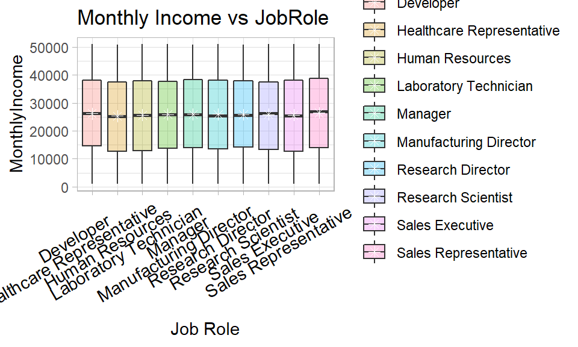

Figure 1: Monthly income vs Job role

```r
#Box Plot
  ggplot(ibm_data_df, aes(x = factor(JobRole), y = MonthlyIncome, fill = JobRole)) +
  geom_boxplot(alpha=0.3) + ggtitle("Monthly Income vs JobRole") + xlab("Job Role") + theme_light() +
  stat_summary(fun = "mean", geom = "point", shape = 8,
               size = 2, color = "white") + theme(axis.text.x=element_text(color = "black", size=11,   angle=30, vjust=.8, hjust=0.8))
```

## Business Question: Is the attrition in woman employees Higher than their Male Counterparts ?

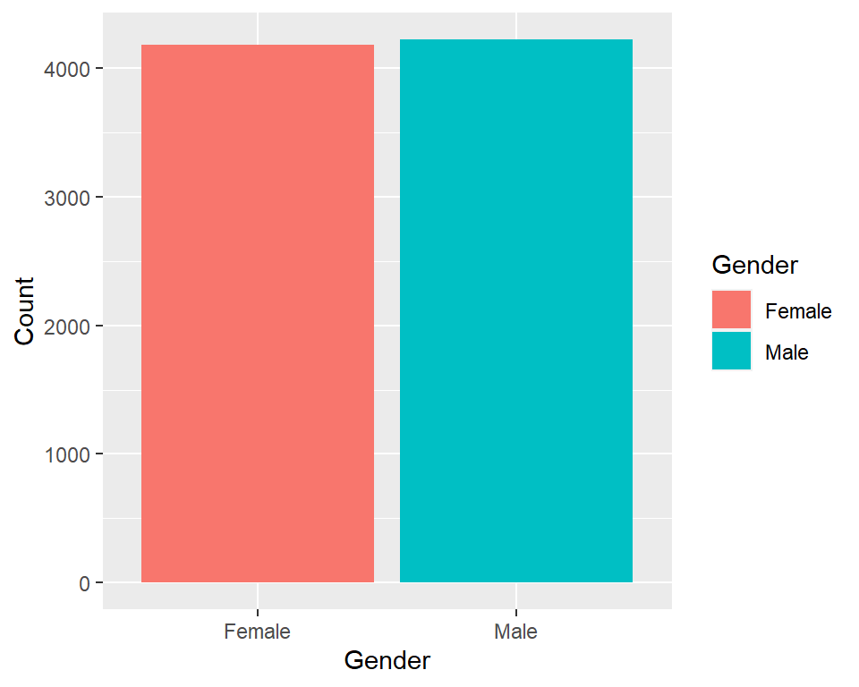

```r
library(dplyr)
Attrited<- ibm_data_df %>% dplyr::select (Attrition,Gender) %>% filter(Attrition=="Yes") %>% group_by(Gender) %>% summarize(Count=n())

ggplot(data=Attrited, aes(x=Gender, y=Count ,fill=Gender)) + geom_col()
```

- It is quite possible that job attrition may seem to be higher in woman than male or vice versa.
- From the analysis of the data, we find that the attrition is marginally higher in male than female.

### Business Problem Questions:

- Do parameters like Working in a company for for years affect the attrition?
- Would you quit a company even if the number of years you have served in a current role is more?
- Do you quit a company if you work with a manager and don’t like working under him?
- Does your promotion count affect the job attrition?
- Comparing attrition with factors like `years at the company`,`years in current role`,`Last`  
  `promotion received`, `experience in holding work experience` with the current manager.

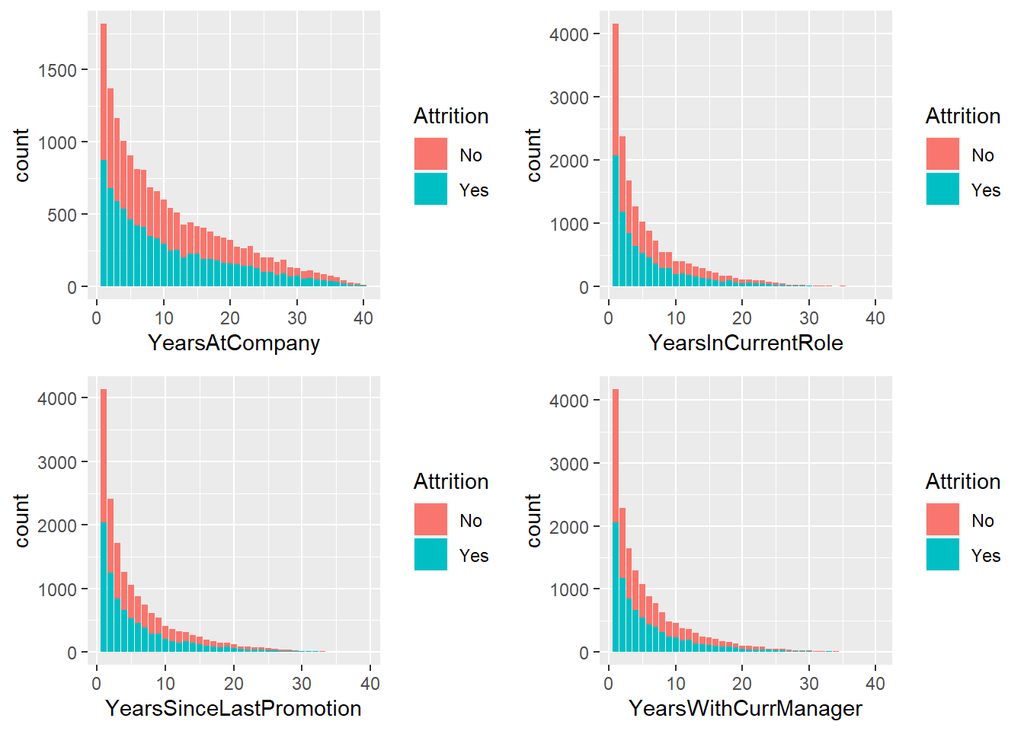

```r
Yr_Com <- ggplot(ibm_data_df,aes(YearsAtCompany,fill = Attrition))+geom_bar()
Yr_Cur <- ggplot(ibm_data_df,aes(YearsInCurrentRole,fill = Attrition))+geom_bar()
Yr_LstProm <- ggplot(ibm_data_df,aes(YearsSinceLastPromotion,fill = Attrition))+geom_bar()
Yr_CurMan <- ggplot(ibm_data_df,aes(YearsWithCurrManager,fill = Attrition))+geom_bar()
grid.arrange(Yr_Com,Yr_Cur,Yr_LstProm,Yr_CurMan,ncol=2)
```

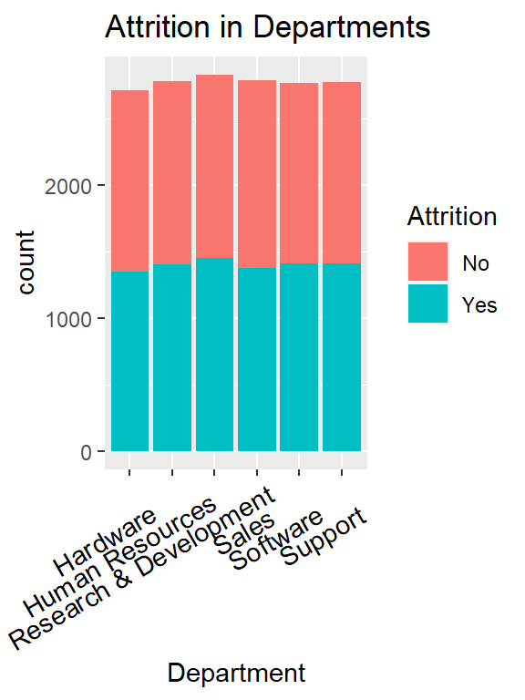

Figure 5: Descriptive Stats

```r
dep_ibm <- ggplot(ibm_data_df,aes(Department,fill = Attrition))+geom_bar() + theme(axis.text.x=element_text(color = "black", size=11,   angle=30, vjust=.8, hjust=0.8)) +ggtitle("Attrition in Departments")
dep_ibm
```

- The above graph depicts that Research and development has higher attrition as compared to the other departments in IBM but the inference may be incorrect.

### Business Problem: Which parameters are strong indicators of Attrition?

- Correlation is used to understand the linear relationship between the two parameters.
- Correlation greater than 0.70% is considered to be strong.
- We have explored the variables with quantitative values to get a better gist of what’s happening in the company and what may be a predominant factor leading to a high job attrition of the company.

```r
Var1<-subset(ibm_data_df,select=c(Age,TotalWorkingYears,MonthlyIncome,YearsAtCompany,YearsInCurrentRole,YearsWithCurrManager,YearsSinceLastPromotion))

Cor_frame<-as.data.frame(cor(Var1))

cor(Cor_frame)
```

```
                               Age TotalWorkingYears MonthlyIncome
Age                      1.0000000        -0.5427304    -0.1856576
TotalWorkingYears       -0.5427304         1.0000000    -0.5478574
MonthlyIncome           -0.1856576        -0.5478574     1.0000000
YearsAtCompany          -0.6089261         0.7926603    -0.6185864
YearsInCurrentRole      -0.5740721         0.6588892    -0.5623964
YearsWithCurrManager    -0.5610930         0.6568147    -0.5671331
YearsSinceLastPromotion -0.5577348         0.6522668    -0.5699604
                        YearsAtCompany YearsInCurrentRole YearsWithCurrManager
Age                         -0.6089261         -0.5740721           -0.5610930
TotalWorkingYears            0.7926603          0.6588892            0.6568147
MonthlyIncome               -0.6185864         -0.5623964           -0.5671331
YearsAtCompany               1.0000000          0.8974181            0.8921880
YearsInCurrentRole           0.8974181          1.0000000            0.7584560
YearsWithCurrManager         0.8921880          0.7584560            1.0000000
YearsSinceLastPromotion      0.8911620          0.7617989            0.7414147
                        YearsSinceLastPromotion
Age                                  -0.5577348
TotalWorkingYears                     0.6522668
MonthlyIncome                        -0.5699604
YearsAtCompany                        0.8911620
YearsInCurrentRole                    0.7617989
YearsWithCurrManager                  0.7414147
YearsSinceLastPromotion               1.0000000
```

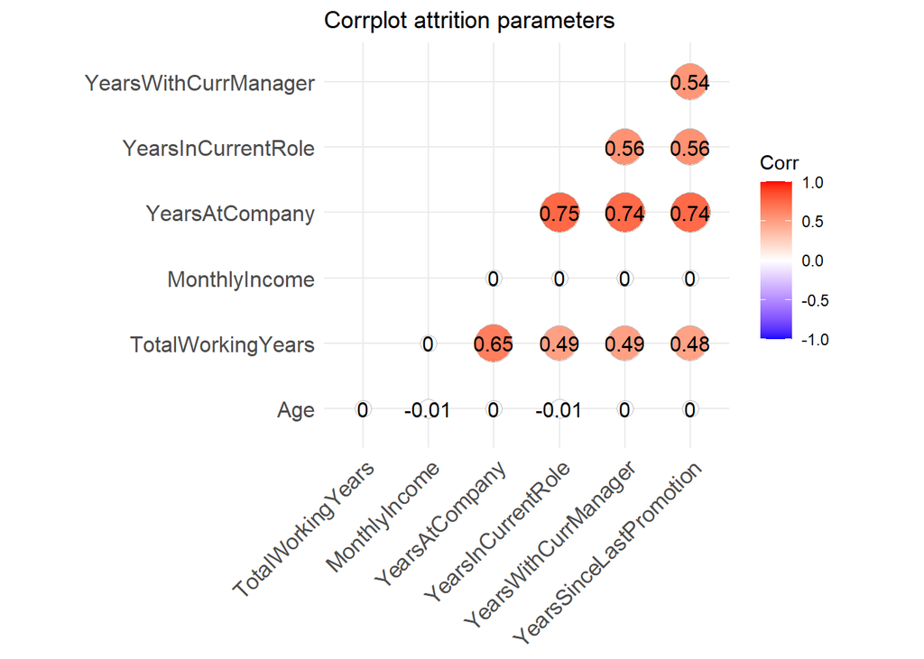

Figure 6: Correlation amongst Variables to understand Attrition

```r
ggcorrplot::ggcorrplot(cor(Var1),method = "circle",title = "Corrplot attrition parameters",type ="lower" ,lab = TRUE)
```

- The above graph shows that years at company has a strong correlation with years in current role , years with current manager and years since last promotion, i.e- 0.75, 0.74,0.74 respectively.
- We can use str to understand if the variable has factors or it is a numerical variable.

## Inferential Statistics

### Chi Square Test

```r
#str(ibm_data_df)

table1 = as.table(table(ibm_data_df$Attrition,ibm_data_df$Department))
prop.table(table1)
```

```
        Hardware Human Resources Research & Development      Sales   Software
  No  0.08184327      0.08250330             0.08250330 0.08496340 0.08160326
  Yes 0.08094324      0.08436337             0.08730349 0.08268331 0.08448338

         Support
  No  0.08226329
  Yes 0.08454338
```

```r
print(chisq.test(table(table1)))
```

```
Warning in chisq.test(table(table1)): Chi-squared approximation may be incorrect
```

```
    Chi-squared test for given probabilities

data:  table(table1)
X-squared = 0.83333, df = 10, p-value = 0.9999
```

…….

### Business Question: Is there relation between job attrition and the department in which people work?

- It is quite possible that certain departments face more attrition than the rest.
- Using a `Chi- Square` test and a plot to determine the same.

```r
test <- chisq.test(table(table1))
```

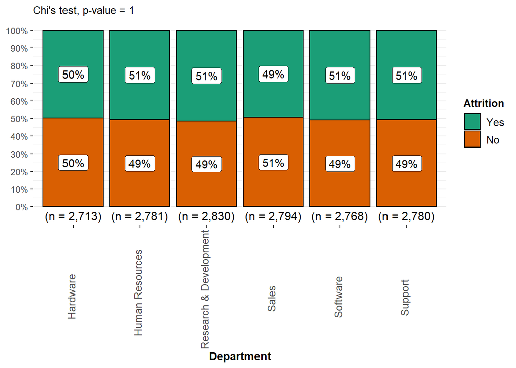

Figure 7: Chi Test

```r
library(ggstatsplot)
ggbarstats(
  ibm_data_df, Attrition, Department,
  results.subtitle = FALSE,
  subtitle = paste0(
    "Chi's test", ", p-value = ",
    ifelse(test$p.value < 0.001, "< 0.001", round(test$p.value, 3))
  )
) + theme(axis.text.x=element_text(size=10, angle=90,hjust=0.4,vjust=0.2))
```

- Ho: The attrition is independent of the Department in which the employee works.(N=16,666)
- H1: The attrition value is dependent on the department in which the employee works (N=16,666)
- Here attrition is the dependent variable and Department is the independent variable.
- From the result obtained, since the p value is greater than the significance value of 0.05, we fail to reject the Null Hypothesis.
- `Difficulties Faced:` Even though the sample size is unbalanced with different levels for the dependent and independent variables, basing the assumption on the p value may be incorrect. Not able to perform a fisher’s test or a Kolmogorov Smiro Test due to differences in the levels of the variables taken.
- Since the data has been been segregated from the parent data set the results obtained here are reflecting roughly an equal percentage to the attrition levels.( both no and yes variate from 49-51 percentage)

### Anova Test

- A two-way ANOVA test is a statistical test that is used to see how two nominal predictor variables affect a continuous outcome variable. The effect of the independent factors on the expected  
  outcome, as well as their connection to the outcome, is investigated using a two-way ANOVA test.
- With the two-way ANOVA, there are three basic forms of hypotheses-
- The first factor’s population means are equal.
- The second factor’s population means are equal.
- The two variables do not interact in any way.

## Business Question: We are conducting an Anova to study if the Education and Gender are parameters in deciding the monthly income.

Ho: There is no difference in the avg mean of any levels of the education field

Ho: There is no difference in the avg mean of any levels of the Gender field

Ho: There is no interaction between the variables of Gender and Education

H1:Difference exists between the means of the factors of the Education variable.

H1:Difference exists between the means of the factors of the Gender Variable

H1:There is significant interaction between Gender and Education variables.

```r
two_wayanova<- aov(MonthlyIncome ~ factor(Gender) + factor(Education), data = ibm_data_df)

summary(two_wayanova)   # first test
```

```
                     Df    Sum Sq   Mean Sq F value Pr(>F)
factor(Gender)        1 5.581e+08 558089091   2.708 0.0998 .
factor(Education)     4 7.776e+08 194401593   0.943 0.4376
Residuals         16660 3.433e+12 206069207
---
Signif. codes:  0 '***' 0.001 '**' 0.01 '*' 0.05 '.' 0.1 ' ' 1
```

```r
IBM_aov <- aov(MonthlyIncome ~ factor(EducationField) + factor(Gender)+factor(Education):factor(Gender), data = ibm_data_df)   # test for interaction
summary(IBM_aov)
```

```
                                    Df    Sum Sq   Mean Sq F value Pr(>F)
factor(EducationField)               5 7.904e+08 158072869   0.767  0.573
factor(Gender)                       1 5.470e+08 547032042   2.654  0.103
factor(Gender):factor(Education)     8 1.513e+09 189066281   0.917  0.501
Residuals                        16651 3.432e+12 206089649
```

```r
Tukey_ibm <- TukeyHSD(IBM_aov)

Tukey_ibm
```

```
  Tukey multiple comparisons of means
    95% family-wise confidence level

Fit: aov(formula = MonthlyIncome ~ factor(EducationField) + factor(Gender) + factor(Education):factor(Gender), data = ibm_data_df)

$`factor(EducationField)`
                                       diff        lwr       upr     p adj
Life Sciences-Human Resources     346.01126  -750.5200 1442.5425 0.9467672
Marketing-Human Resources         660.14847  -452.7940 1773.0909 0.5380729
Medical-Human Resources           283.09112  -804.5788 1370.7610 0.9766957
Other-Human Resources             584.62574  -508.2231 1677.4745 0.6482999
Technical Degree-Human Resources  248.72087  -851.2806 1348.7224 0.9876016
Marketing-Life Sciences           314.13721  -797.7378 1426.0122 0.9666643
Medical-Life Sciences             -62.92014 -1149.4977 1023.6575 0.9999831
Other-Life Sciences               238.61448  -853.1472 1330.3761 0.9893827
Technical Degree-Life Sciences    -97.29039 -1196.2118 1001.6310 0.9998617
Medical-Marketing                -377.05735 -1480.1942  726.0796 0.9262176
Other-Marketing                   -75.52273 -1183.7662 1032.7208 0.9999621
Technical Degree-Marketing       -411.42760 -1526.7251  703.8699 0.9003401
Other-Medical                     301.53462  -781.3267 1384.3959 0.9686895
Technical Degree-Medical          -34.37025 -1124.4498 1055.7093 0.9999992
Technical Degree-Other           -335.90487 -1431.1519  759.3422 0.9527318

$`factor(Gender)`
                 diff       lwr      upr     p adj
Male-Female -362.2846 -798.2263 73.65713 0.1033478

$`factor(Gender):factor(Education)`
                         diff        lwr       upr     p adj
Male:1-Female:1     267.50026 -1294.0032 1829.0038 0.9999430
Female:2-Female:1   395.52658 -1178.9830 1970.0362 0.9986704
Male:2-Female:1     328.72824 -1241.6064 1899.0629 0.9996952
Female:3-Female:1   680.81276  -884.7057 2246.3312 0.9346976
Male:3-Female:1    -221.43557 -1789.1087 1346.2376 0.9999891
Female:4-Female:1    96.39472 -1471.7600 1664.5494 1.0000000
Male:4-Female:1    -379.58303 -1931.9140 1172.7480 0.9989265
Female:5-Female:1   815.76603  -754.8121 2386.3441 0.8267014
Male:5-Female:1     180.85591 -1380.4136 1742.1254 0.9999981
Female:2-Male:1     128.02631 -1452.1916 1708.2442 0.9999999
Male:2-Male:1        61.22797 -1514.8301 1637.2860 1.0000000
```

[output cut: 19 more lines]

```
Male:3-Female:3    -902.24833 -2479.6392  675.1425 0.7291889
Female:4-Female:3  -584.41804 -2162.2875  993.4514 0.9765677
Male:4-Female:3   -1060.39579 -2622.5399  501.7484 0.4933688
Female:5-Female:3   134.95327 -1445.3247 1715.2312 0.9999999
Male:5-Female:3    -499.95685 -2070.9837 1071.0700 0.9919350
Female:4-Male:3     317.83029 -1262.1771 1897.8376 0.9997807
Male:4-Male:3      -158.14746 -1722.4510 1406.1560 0.9999994
Female:5-Male:3    1037.20160  -545.2110 2619.6142 0.5461129
Male:5-Male:3       402.29148 -1170.8825 1975.4655 0.9984698
Male:4-Female:4    -475.97775 -2040.7639 1088.8084 0.9942166
Female:5-Female:4   719.37131  -863.5184 2302.2610 0.9153891
Male:5-Female:4      84.46119 -1489.1927 1658.1151 1.0000000
Female:5-Male:4    1195.34906  -371.8657 2762.5638 0.3176436
Male:5-Male:4       560.43894  -997.4471 2118.3250 0.9807816
Male:5-Female:5    -634.91011 -2210.9790  941.1588 0.9593330
```

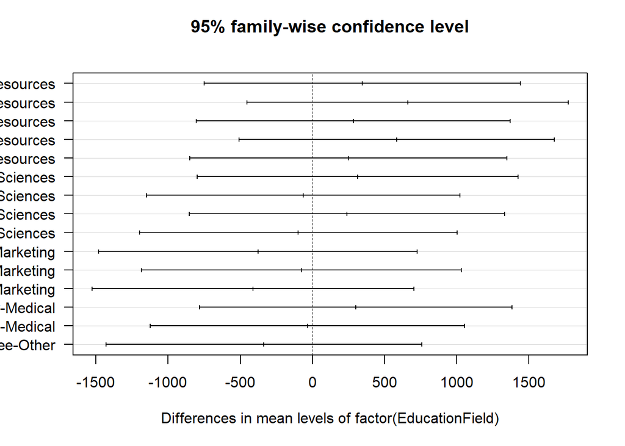

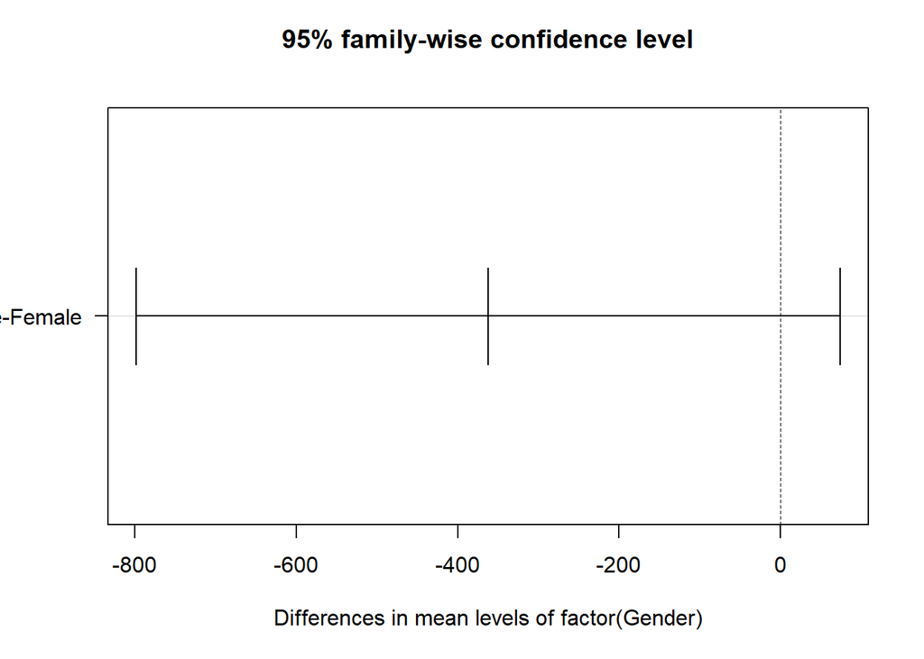

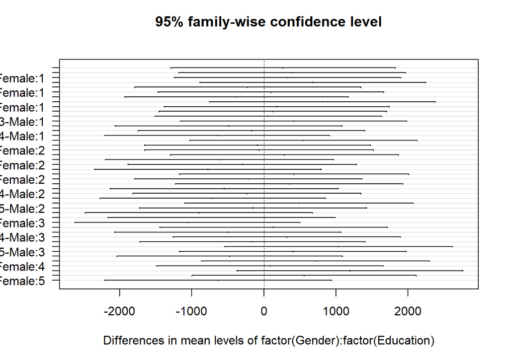

```r
plot(Tukey_ibm, las = 1)
```

## Conclusion

- As per my report the Males are more prone to leave a job as compared to women.
- People from Research Department may tend to leave the job more as compared to the others. The data maybe biased because I have received the data randomly from the file.
- The hypothesis, where we derived the Chi square test states that the department and attrition don’t have a strong relation.
- For a two way Anova test, there is not much statistical difference between the various groups, after performing the tukey test.

## References:

- Chi-square Test with High Sample Size and Unbalanced Data. (2019, December 11). Cross Validated. https://stats.stackexchange.com/questions/440371/chi-square-test-with-high-sample-size-and-unbalanc ed-data
- Chandrasekharan, S. (2019). [PDF] Statistical Issues in Small and Large Sample: Need of Optimum Upper Bound for the Sample Size | Semantic Scholar. Https://Www.Semanticscholar.Org/.  
  https://www.semanticscholar.org/paper/Statistical-Issues-in-Small-and-Large-Sample%3A-Need-Chandras ekharan-Sreedharan/22ebf6f3a30e75b4240c8fcee93dce27066e11ff.
- Singh, N. K. (2020, October 29). Exploratory Data Analysis in R with Tidyverse. Pluralsight.  
  https://www.pluralsight.com/guides/exploratory-data-analysis-in-r
- Bevans, R. (2021, July 1). ANOVA in R: A step-by-step guide. Scribbr. https://www.scribbr.com/statistics/anova-in-r/#anova-graph